# Customer Segmentation -Hierarchical Clustering

## Hierarchical Clustering

```python
# Creating empty list to append the values
corr = []
metric = []
link = []

# list of distance metrics
distance_metrics = ["euclidean", "cityblock"]

# list of linkage methods
linkage_methods = ["single", "complete", "average", "weighted"]

for dm in distance_metrics:
    for lm in linkage_methods:
        Z = linkage(df_scaled_subset, metric=dm, method=lm)
        c, coph_dists = cophenet(Z, pdist(df_scaled_subset))
        print(
            "Cophenetic correlation for {} distance and {} linkage is {}.".format(
                dm.capitalize(), lm, c
            )
        )
        corr.append(c)
        metric.append(dm)
        link.append(lm)
```

```
Cophenetic correlation for Euclidean distance and single linkage is 0.7391220243806552.
Cophenetic correlation for Euclidean distance and complete linkage is 0.8599730607972423.
Cophenetic correlation for Euclidean distance and average linkage is 0.8977080867389372.
Cophenetic correlation for Euclidean distance and weighted linkage is 0.8861746814895477.
Cophenetic correlation for Cityblock distance and single linkage is 0.7252379350252723.
Cophenetic correlation for Cityblock distance and complete linkage is 0.8731477899179829.
Cophenetic correlation for Cityblock distance and average linkage is 0.896329431104133.
Cophenetic correlation for Cityblock distance and weighted linkage is 0.8825520731498188.
```

```python
Correlation_frame = pd.DataFrame(
    {"Distance metric": metric, "Linkage Method": link, "Cophenetic Corr": corr}
)
Correlation_frame.sort_values(by="Cophenetic Corr", ascending=False)
```

|  | Distance metric | Linkage Method | Cophenetic Corr |
| --- | --- | --- | --- |
| 2 | euclidean | average | 0.897708 |
| 6 | cityblock | average | 0.896329 |
| 3 | euclidean | weighted | 0.886175 |
| 7 | cityblock | weighted | 0.882552 |
| 5 | cityblock | complete | 0.873148 |
| 1 | euclidean | complete | 0.859973 |
| 0 | euclidean | single | 0.739122 |
| 4 | cityblock | single | 0.725238 |

**Observations**

- We see that the Average Linkage method for Euclidean and Cityblock distance metrics has the highest cophenetic correlations.

**Euclidean Distance metric- Let's explore the different linkage methods**

```python
# list of linkage methods
linkage_methods = ["single", "complete", "average", "centroid", "ward", "weighted"]

# creating a empty list to store the highest values
high_cophenet_coff = 0
high_lm = [0, 0]

for lm in linkage_methods:
    Z = linkage(df_scaled_subset, metric="euclidean", method=lm)
    c, coph_dists = cophenet(Z, pdist(df_scaled_subset))
    print("Cophenetic correlation for {} linkage is {}.".format(lm, c))
    if high_cophenet_coff < c:
        high_cophenet_coff = c
        high_lm[0] = "euclidean"
        high_lm[1] = lm
```

```
Cophenetic correlation for single linkage is 0.7391220243806552.
Cophenetic correlation for complete linkage is 0.8599730607972423.
Cophenetic correlation for average linkage is 0.8977080867389372.
Cophenetic correlation for centroid linkage is 0.8939385846326323.
Cophenetic correlation for ward linkage is 0.7415156284827493.
Cophenetic correlation for weighted linkage is 0.8861746814895477.
```

### Creating Dendograms for the different linkage methods

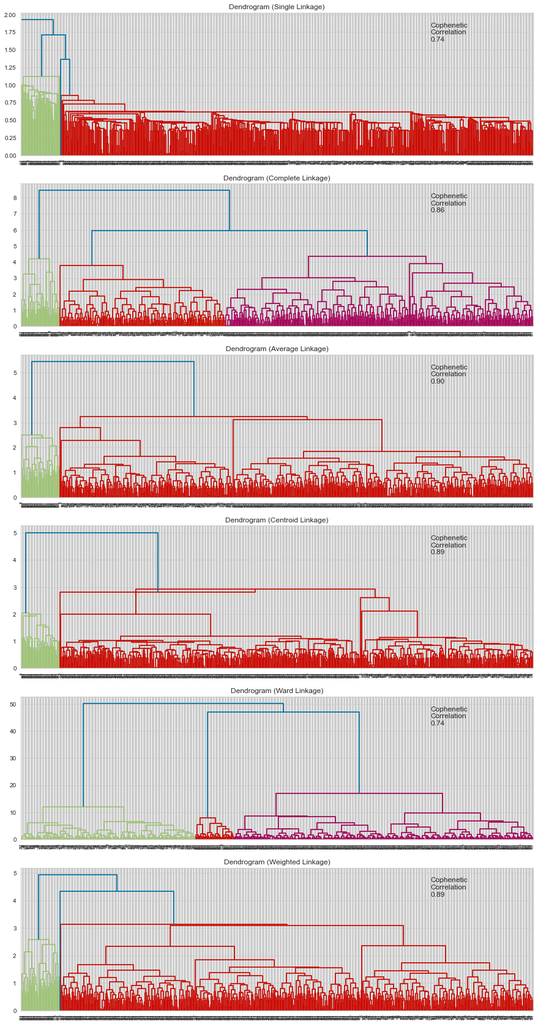

```python
# to create a subplot image
fig, axs = plt.subplots(len(linkage_methods), 1, figsize=(15, 30))

# For each linkage method, we will plot the dendrogram and calculate the cophenetic correlation
for i, lm in enumerate(linkage_methods):
    Z = linkage(df_scaled_subset, metric="euclidean", method=lm)

    dendrogram(Z, ax=axs[i])
    axs[i].set_title(f"Dendrogram ({lm.capitalize()} Linkage)")

    coph_corr, coph_dist = cophenet(Z, pdist(df_scaled_subset))
    axs[i].annotate(
        f"Cophenetic\nCorrelation\n{coph_corr:0.2f}",
        (0.80, 0.80),
        xycoords="axes fraction",
    )
```

**Observations**

- We see from the above diagrams that despite having a high cophenetic correlation, the clustes are not very distinct for Average Linkage.
- We see that the dendogram for Ward linkage has better and distinct clusters.

**Manhattan(Cityblock) Distance metric- Let's explore the different linkage methods**

```python
# list of linkage methods
linkage_methods1 = ["single", "complete", "average", "weighted"]

# creating a empty list to store the highest values
high_cophenet_coff_man = 0
high_lm_man = [0, 0]

for lm in linkage_methods1:
    Z = linkage(df_scaled_subset, metric="cityblock", method=lm)
    c, coph_dists = cophenet(Z, pdist(df_scaled_subset))
    print("Cophenetic correlation for {} linkage is {}.".format(lm, c))
    if high_cophenet_coff_man < c:
        high_cophenet_coff_man = c
        high_lm_man[0] = "Manhattan"
        high_lm_man[1] = lm
```

```
Cophenetic correlation for single linkage is 0.7252379350252723.
Cophenetic correlation for complete linkage is 0.8731477899179829.
Cophenetic correlation for average linkage is 0.896329431104133.
Cophenetic correlation for weighted linkage is 0.8825520731498188.
```

### Creating Dendograms for the different linkage methods

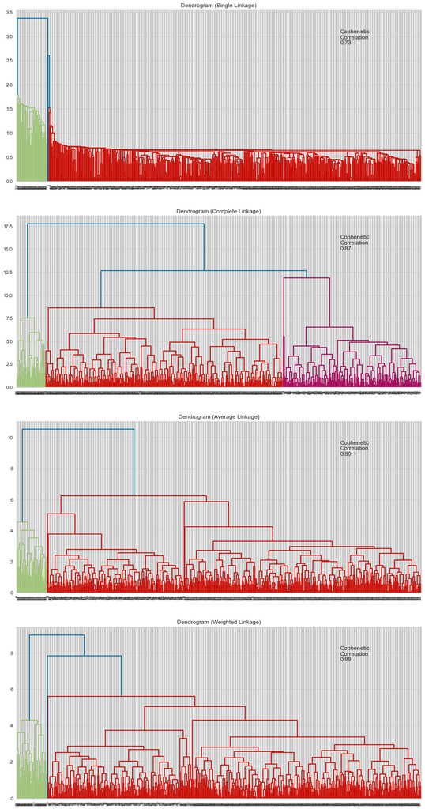

```python
# to create a subplot image
fig, axs = plt.subplots(len(linkage_methods1), 1, figsize=(15, 30))

# For each linkage method, we will plot the dendrogram and calculate the cophenetic correlation
for i, lm in enumerate(linkage_methods1):
    Z = linkage(df_scaled_subset, metric="cityblock", method=lm)

    dendrogram(Z, ax=axs[i])
    axs[i].set_title(f"Dendrogram ({lm.capitalize()} Linkage)")

    coph_corr, coph_dist = cophenet(Z, pdist(df_scaled_subset))
    axs[i].annotate(
        f"Cophenetic\nCorrelation\n{coph_corr:0.2f}",
        (0.80, 0.80),
        xycoords="axes fraction",
    )
```

**Observations**

- From the above dendograms, we see that Complete Linkage has better and distinct clusters than Average linkage for Manhattan(Cityblock) distance metric

**Observations:**

- Cophenetic correlation for Average linkage is the highest, but we see from the dendogram that the clusters are not very distinct.

### Final Observations:

**Cluster Profile with Manhattan Distance and Complete Linkage**

```python
HC_model = AgglomerativeClustering(
    n_clusters=5, affinity="cityblock", linkage="complete"
)
HC_model.fit(df_scaled_subset)
```

```
AgglomerativeClustering(affinity='cityblock', linkage='complete', n_clusters=5)
```

```python
# Applying the clusters to the original and scaled dataset
df_scaled_subset["HC_Clusters"] = HC_model.labels_
df2 = df.copy()
df2["HC_Clusters"] = HC_model.labels_
df2.head()
```

|  | Avg_Credit_Limit | Total_Credit_Cards | Total_visits_bank | Total_visits_online | Total_calls_made | Credit_Limit_Bin | HC_Clusters |
| --- | --- | --- | --- | --- | --- | --- | --- |
| 0 | 100000 | 2 | 1 | 1 | 0 | <100000 | 4 |
| 1 | 50000 | 3 | 0 | 10 | 9 | <50000 | 3 |
| 2 | 50000 | 7 | 1 | 3 | 4 | <50000 | 1 |
| 3 | 30000 | 5 | 1 | 1 | 4 | <50000 | 1 |
| 4 | 100000 | 6 | 0 | 12 | 3 | <100000 | 3 |

```python
cluster_profile_HC = df2.groupby("HC_Clusters").mean()
```

```python
# Let's count how many rows are there in each cluster
cluster_profile_HC["Total_count_per_segment"] = (
    df2.groupby("HC_Clusters")["Credit_Limit_Bin"].count().values
)
```

```python
# display the cluster profiles
cluster_profile_HC.style.highlight_max(color="lightblue", axis=0)
```

| HC_Clusters | Avg_Credit_Limit | Total_Credit_Cards | Total_visits_bank | Total_visits_online | Total_calls_made | Total_count_per_segment |
| --- | --- | --- | --- | --- | --- | --- |
| 0 | 142750.000000 | 8.875000 | 0.625000 | 10.875000 | 1.020833 | 48 |
| 1 | 32605.898123 | 5.560322 | 3.544236 | 0.981233 | 2.037534 | 373 |
| 2 | 12027.027027 | 2.400901 | 0.932432 | 3.531532 | 6.873874 | 222 |
| 3 | 83333.333333 | 4.666667 | 0.000000 | 11.000000 | 4.666667 | 3 |
| 4 | 63214.285714 | 4.214286 | 1.928571 | 1.071429 | 1.142857 | 14 |

**Observation**

- Clusters 1 & 2 have majority of the data and the rest are grouped between the remaining clusters.
- This clustering doesnt seem to have enough variability

**Cluster Profile with Euclidean Distance and Ward Linkage**

```python
HC_model1 = AgglomerativeClustering(n_clusters=5, affinity="euclidean", linkage="ward")
HC_model1.fit(df_scaled_subset)
```

```
AgglomerativeClustering(n_clusters=5)
```

```python
df3 = df.copy()  # making a copy
df3["HC_Clusters"] = HC_model1.labels_
df3.head()
```

|  | Avg_Credit_Limit | Total_Credit_Cards | Total_visits_bank | Total_visits_online | Total_calls_made | Credit_Limit_Bin | HC_Clusters |
| --- | --- | --- | --- | --- | --- | --- | --- |
| 0 | 100000 | 2 | 1 | 1 | 0 | <100000 | 3 |
| 1 | 50000 | 3 | 0 | 10 | 9 | <50000 | 0 |
| 2 | 50000 | 7 | 1 | 3 | 4 | <50000 | 4 |
| 3 | 30000 | 5 | 1 | 1 | 4 | <50000 | 4 |
| 4 | 100000 | 6 | 0 | 12 | 3 | <100000 | 0 |

```python
cluster_profile_HC1 = df3.groupby("HC_Clusters").mean()
```

```python
# Let's count how many rows are there in each cluster
cluster_profile_HC1["Total_count_per_segment"] = (
    df3.groupby("HC_Clusters")["Credit_Limit_Bin"].count().values
)
```

```python
# display the cluster profiles
cluster_profile_HC1.style.highlight_max(color="lightblue", axis=0)
```

| HC_Clusters | Avg_Credit_Limit | Total_Credit_Cards | Total_visits_bank | Total_visits_online | Total_calls_made | Total_count_per_segment |
| --- | --- | --- | --- | --- | --- | --- |
| 0 | 12977.777778 | 2.431111 | 0.920000 | 3.631111 | 6.844444 | 225 |
| 1 | 32862.244898 | 5.285714 | 4.377551 | 1.066327 | 1.785714 | 196 |
| 2 | 142750.000000 | 8.875000 | 0.625000 | 10.875000 | 1.020833 | 48 |
| 3 | 63214.285714 | 4.214286 | 1.928571 | 1.071429 | 1.142857 | 14 |
| 4 | 32322.033898 | 5.864407 | 2.621469 | 0.887006 | 2.316384 | 177 |

**Observations**

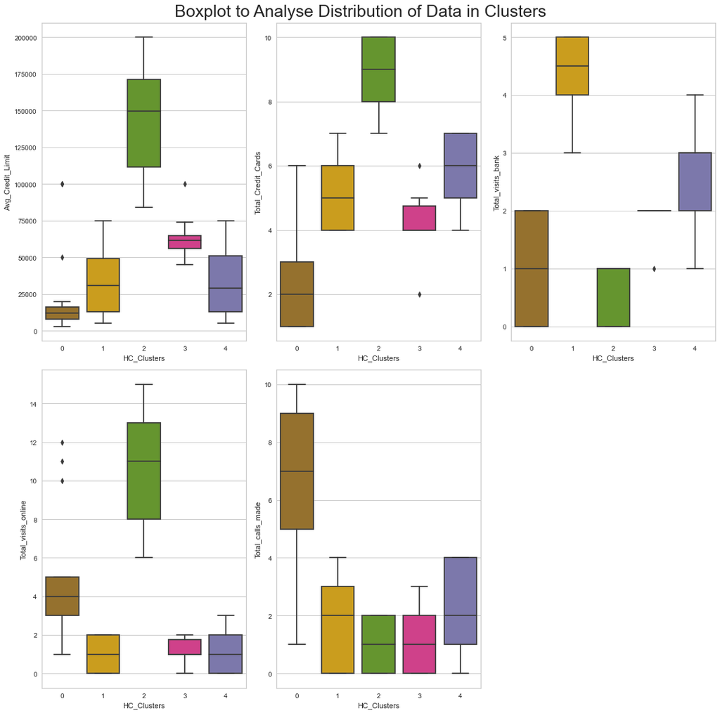

```python
num_col = [
    "Avg_Credit_Limit",
    "Total_Credit_Cards",
    "Total_visits_bank",
    "Total_visits_online",
    "Total_calls_made",
]

plt.figure(figsize=(15, 15))
plt.suptitle("Boxplot to Analyse Distribution of Data in Clusters", fontsize=25)
sns.set_palette("Dark2_r")
for i in range(0, 5):
    plt.subplot(2, 3, i + 1)
    sns.boxplot(x=df3["HC_Clusters"], y=df3[num_col[i]])
    plt.tight_layout()
```

## Cluster Insights:

**Cluster 0**

- There are 225 customers in this cluster
- Average_Credit_Limit for this cluster is low with mean of about \$13000. However, there are two customers who have a high Credit limit of \\$50,000 and \$100,000 respectively.
- Most customers in this clusters have between 1-3 Total_Credit_Cards.But we see that the upper whisker is at 6. This could correlate to the customers with high credit limits in this cluster.
- Total_visits_bank is at a lower end between 0-2.
- Majority of customers have between 3-5 Total_visits_online values, with three outliers in the high end at 10,11 & 12 respectively.
- Interestingly, Most customers in this cluster have higher Total_calls_made,with values between 5-9.

**Cluster 1**

- There are 196 customers in this cluster
- Average_Credit_Limit is between appros \$13,000 to \\$50,000 for most customers
- Total_Credit_Cards is moderate at 4-6 cards
- Most Customers in this cluster have higher bank vists, between 4-5.
- Total_visits_online is lower
- Total_calls_made is between 0-3 for most customers

**Cluster 2**

- There are only 48 customers in this cluster
- Avg_Credit_Limit is high for this cluster, with the median at \$150,000
- Likewise, Total_Credit_Cards is also high.
- Customers in this clusters have a low Total_visits_bank with median of only 1
- Total_visits_online is also the highest compared to other clusters
- Most customers here have Total_calls_made value of only 1.

**Cluster 3**

**Cluster 4**

- There are 177 customers in this cluster
- The median Avg_Credit_limit is similar to cluster one, at around approx \$30,000
- The Total_Credit_Cards range is between 5-7 for most customes.
- Total_visits_bank is moderate, between 2 to 3
- Total_visits_online is low
- Total_calls made is between 1-4 for most customers

### Comparing Cluster Profile with Credit_Limit_Bin

```python
pd.crosstab(df3["HC_Clusters"], df3["Credit_Limit_Bin"]).style.highlight_max(
    color="lightpink", axis=0
)
```

| Credit_Limit_Bin HC_Clusters | <25000 | <50000 | <100000 | <150000 | <200000 |
| --- | --- | --- | --- | --- | --- |
| 0 | 222 | 1 | 2 | 0 | 0 |
| 1 | 84 | 68 | 44 | 0 | 0 |
| 2 | 0 | 0 | 9 | 15 | 24 |
| 3 | 0 | 1 | 13 | 0 | 0 |
| 4 | 85 | 47 | 45 | 0 | 0 |